# 606-HW4

Joseph Elikishvili

October 14, 2016

## 4.4

1. point estimate = 171.1, midean = 171.1
2. 9.4, IQR = 177.8-163.8=14
3. 180 falls within 1SD so its not considered unusual, 155 is not within 1SD, but is within 2SD, so it is less usual and is closer to 2SD, but still is within 2SD, so I would not call it very unusual.
4. Since it will be a new sample, the mean and SD will be different, although pretty close most likely.
5. 9.4/sqrt(507) = 0.417

## 4.14

1. true
2. False
3. true
4. true
5. true
6. false
7. true

## 4.24

1. While distribuition looks close to normal, it doesn’t exactly fit the perfect normal distribution, so I would like to see a sample size of 100 to account for that.
2. H0 m = 32 Ha m < 32

p=0.034<.10, so we reject the null Hypothesys.

```r
se=4.31/sqrt(36)
x=(32-30.69)/se
p=1-pnorm(x)
p
```

```
## [1] 0.0341013
```

3. p Value is less then the significance value of .10

```r
upper = 30.69 + 1.28*se
lower = 30.69 - 1.28*se
c(lower,upper)
```

```
## [1] 29.77053 31.60947
```

## 4.26

1. H0 m = 100 Ha m!= 100

```r
se=6.5/sqrt(36)
z=(100-118.2)/se
p=1-pnorm(z)
```

```r
upper = 118.2 + 1.28*se
lower = 118.2 - 1.28*se
c(lower,upper)
```

```
## [1] 116.8133 119.5867
```

3. Yes results agree as 100 is not part of the range.

## 4.34

Sampling distribution is the distribution of samples taken out of the population. So lets say we take 50 samples and then create a distribution of the means of those samples. The higher is the numbner of samples the closer the distribution will reseble the normal distribution.

## 4.40

1. 6.7%

```r
1500/1000
```

```
## [1] 1.5
```

```r
1-pnorm(1.5)
```

```
## [1] 0.0668072
```

```r
se = 1000/sqrt(15)
upper = 9000 + 1.28*se
lower = 9000 - 1.28*se
c(lower,upper)
```

```
## [1] 8669.505 9330.495
```

3. We would need to move 5+ standard deviations in order to reach 10500, so the probability wouldbe extremly low.

```r
z = (10500-9000)/se
1-pnorm(z)
```

```
## [1] 3.133452e-09
```

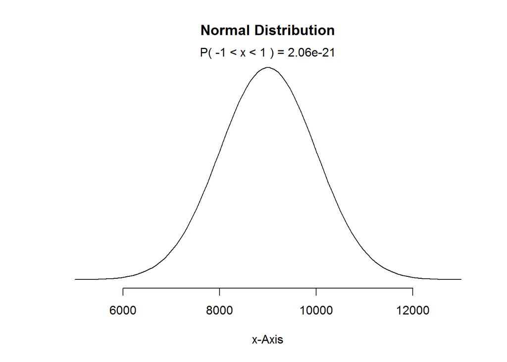

```r
normalPlot(mean = 9000, sd = 1000)
```

5. No, we only have a sample of 15 we would need a sample of at least 100 to work with a a skewed distribution.

## 4.48

As we get more data, variablity of the data will decrease and we should have readfings very close to the actual population. So p value generally should deacrese.